# TP3

Benjamin Hivert (benjamin.hivert@u-bordeaux.fr)

22 Septembre 2024

On s’intéresse dans ce TP à deux bases de données relatives aux accidents de la route en France en 2018. Les deux bases de données peuvent être reliées grâce à la variable `Num_Acc` (l’identifiant de l’accident).

La première base `caracteristiques.csv` contient des informations décrivant les circonstances générales de l’accident. Elle se compose de 7 variables :

- `Num_Acc` : Numéro d’identifiant de l’accident
- `an` : Année
- `mois` : Mois
- `jour` : Le jour
- `lum` : conditions d’éclairage dans lesquelles l’accident s’est produit
  - 1 - Plein jour
  - 2 - Crépuscule ou aube
  - 3 - Nuit sans éclairage publique
  - 4 - Nuit avec éclairage public non allumé
  - 5 - Nuit avec éclairage public allumé
- `agg` : Localisation de l’accident
  - 1 - Hors agglomération
  - 2 - En agglomération
- `dep` : Code Insee du département (suivi d’un 0)

La seconde base (découpée en deux parties), `usager1.csv` et `usager2.csv` donne des informations sur les différents usagers impliqués dans les accidents. Elle comporte 5 variables qui sont :

- `Num_Acc` : Numéro d’identifiant de l’accident
- `catu` : Catégorie d’usager
  - 1 - Conducteur
  - 2 - Passager
  - 3 - Piéton
- `grav` : Gravité de l’accident
  - 1 - Indemne
  - 2 - Tué
  - 3 - Blessé hospitalisé
  - 4 - Blessé léger
- `sexe` : Sexe de l’usager
  - 1 - Masculin
  - 2 - Féminin
- `an_nais` : Année de naissance

# Manipulation de données

1. Importer les fichiers `caracteristiques.csv`, `usager1.csv` et `usager2.csv`

```r
caracteristique <- read.csv(file = "caracteristiques.csv")
usager1 <- read.csv(file = "usager1.csv")
usager2 <- read.csv(file = "usager2.csv")
```

2. Créer un jeu de données `usager` contenant les données de tous les usagers (fonction `rbind()`)

```r
usager <- rbind(usager1, usager2)
```

3. Corriger le type de chaque variable des jeux de données `caracteristique` et `usager`

```r
str(caracteristique)
```

```
## 'data.frame':    55716 obs. of  7 variables:
##  $ Num_Acc: num  2.02e+11 2.02e+11 2.02e+11 2.02e+11 2.02e+11 ...
##  $ an     : int  18 18 18 18 18 18 18 18 18 18 ...
##  $ mois   : int  1 2 3 5 6 9 9 11 2 3 ...
##  $ jour   : int  24 12 4 5 26 23 26 30 18 19 ...
##  $ lum    : int  1 1 1 1 1 2 5 5 1 1 ...
##  $ agg    : int  1 2 2 2 2 2 2 2 1 2 ...
##  $ dep    : int  590 590 590 590 590 590 590 590 590 590 ...
```

```r
caracteristique$Num_Acc <- as.factor(caracteristique$Num_Acc)
caracteristique$lum <- as.factor(caracteristique$lum)
caracteristique$agg  <- as.factor(caracteristique$agg)
caracteristique$dep <- as.factor(caracteristique$dep)

str(usager)
```

```
## 'data.frame':    130169 obs. of  5 variables:
##  $ Num_Acc: num  2.02e+11 2.02e+11 2.02e+11 2.02e+11 2.02e+11 ...
##  $ catu   : int  1 1 1 3 1 1 1 1 1 1 ...
##  $ grav   : int  3 1 1 4 3 1 3 1 4 1 ...
##  $ sexe   : int  1 1 1 1 1 1 1 1 1 1 ...
##  $ an_nais: int  1928 1960 1947 1959 1987 1977 2013 1982 2001 1946 ...
```

```r
usager$Num_Acc <- as.factor(usager$Num_Acc)
usager$catu <- as.factor(usager$catu)
usager$grav <- as.factor(usager$grav)
usager$sexe <- as.factor(usager$sexe)
```

4. Créer un fichier `data` regroupant les deux bases de données (fonction `merge()`)

```r
data <- merge(caracteristique, usager, by = "Num_Acc")
```

5. Créer une variable `date` donnant la date au format **JJ-MM-AA** à partir des variables `jour`, `mois` et `an` (en utilisant la fonction `paste()`)

```r
data$date <- paste(data$jour, data$mois, data$an, sep = "-")
```

6. A l’aide du package `lubridate` (à installer et charger), convertir cette nouvelle variable au format date.

**Aide : https://rawgit.com/rstudio/cheatsheets/main/lubridate.pdf**

```r
library(lubridate)
data$date <- as.Date(data$date, format = "%d-%m-%y")
```

7. A partir de cette variable `date`, créer une variable `saison` (printemps du 20 mars au 20 juin, été du 21 juin au 21 septembre, automne du 22 septembre au 20 décembre, hiver du 21 décembre au 19 mars)

```r
data$saison <- ifelse(data$date<="2018-06-20"&data$date>="2018-03-20",
                      "printemps",
                        ifelse(data$date<="2018-09-21"&data$date>="2018-06-21",
                      "ete",
                        ifelse(data$date<="2018-12-20"&data$date>="2018-09-22",
                      "automne", "hiver")))

## Autre manière de faire : avec une boucle for et des if (beaucoup plus longue)
data$saison2 <- NULL
for (i in 1:nrow(data)){
  if(data$date[i]<="2018-06-20"&data$date[i]>="2018-03-20"){
    data$saison2[i] <- "printemps"
  }
  else{
    if(data$date[i]<="2018-09-21"&data$date[i]>="2018-06-21"){
      data$saison2[i] <- "ete"
    }
    else{
      if(data$date[i]<="2018-12-20"&data$date[i]>="2018-09-22"){
        data$saison2[i] <- "automne"
      }
      else{
        data$saison2[i] <- "hiver"
      }
    }
  }
}

## Autre méthode : avec which
data$saison3 <- rep(NA, nrow(data))
data$saison3[which(data$date<="2018-06-20"&data$date>="2018-03-20")] <- "printemps"
data$saison3[which(data$date<="2018-09-21"&data$date>="2018-06-21")] <- "ete"
data$saison3[which(data$date<="2018-12-20"&data$date>="2018-09-22")] <- "automne"
data$saison3[which(is.na(data$saison3))] <- "hiver"
```

8. Créer une variable `age` indiquant l’âge des usagers au moment de l’accident

```r
data$age <- 2018 - data$an_nais
```

9. A partir de cette variable, créer une variable `alert_mineur` qui vaut 1 si la personne était mineure au moment de l’accident et 0 sinon.

```r
data$alert_mineur <- 1*(data$age<18)
```

11. A l’aide de la fonction `fct_recode` du package `forcats` (à installer et à charger), renommer les modalités des variables qualitatives nominales, `agg`, `grav` et `sexe` afin qu’elles soient plus parlantes

```r
library(forcats)
data$agg <- fct_recode(data$agg,
                       "Hors agglomération" = "1",
                       "En agglomération" = "2")
data$grav <- fct_recode(data$grav,
                        "Indemne" = "1",
                        "Tue" = "2",
                        "Blesse hospitalise" = "3",
                        "Blesse leger"="4")
data$sexe <- fct_recode(data$sexe,
                        "Homme"="1",
                        "Femme" = "2")
```

# Analyse de données

11. Combien de personnes ont été tuées lors d’un accident de la route en 2018 ? Quel pourcentage des accidents de la route cela représente-t-il ?

```r
nb_mort <- sum(data$grav == "Tue")
nb_mort
```

```
## [1] 3244
```

```r
nb_mort/nrow(data)*100
```

```
## [1] 2.587582
```

12. Combien de personnes mineures ont été impliquées dans un accident de la route en 2018? Parmi elles, combien ont été tuées ?

```r
nb_mineur <- sum(data$alert_mineur, na.rm = T)
nb_mineur
```

```
## [1] 11481
```

```r
nb_mineur_tue <- sum(data$alert_mineur & data$grav == "Tue", na.rm = T)
nb_mineur_tue
```

```
## [1] 173
```

13. Afficher le tableau des effectifs du croisement des variables `saison` et `grav` Afficher les fréquences en lignes avec `prop.table()`

```r
tab <- table(data$saison, data$grav)
prop.table(tab, margin = 1)
```

```
##
##                Indemne        Tue Blesse hospitalise Blesse leger
##   automne   0.42414112 0.02513208         0.14924037   0.40148643
##   ete       0.41606950 0.02609026         0.17739624   0.38044400
##   hiver     0.41566528 0.02708705         0.17727543   0.37997224
##   printemps 0.41221774 0.02547673         0.17491759   0.38738794
```

14. Charger `ggplot2`

```r
library(ggplot2)
```

15. Tracer le diagramme en barres empilées présentant la répartition des accidents en fonction du sexe et de la gravité de l’accident

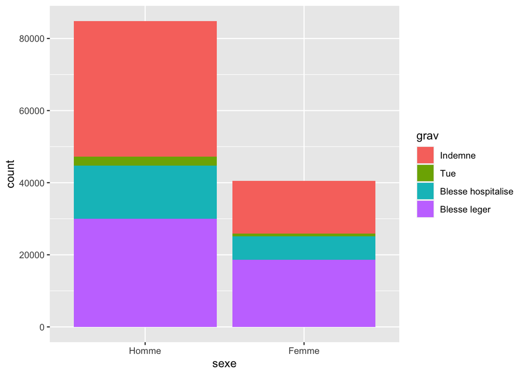

```r
ggplot(data) + aes(x=sexe, fill = grav) + geom_bar()
```

16. Faire de même pour croiser les variables `catu` et `grav`. Changer la couleur ainsi que les labels de la variable `catu` sur le graphique

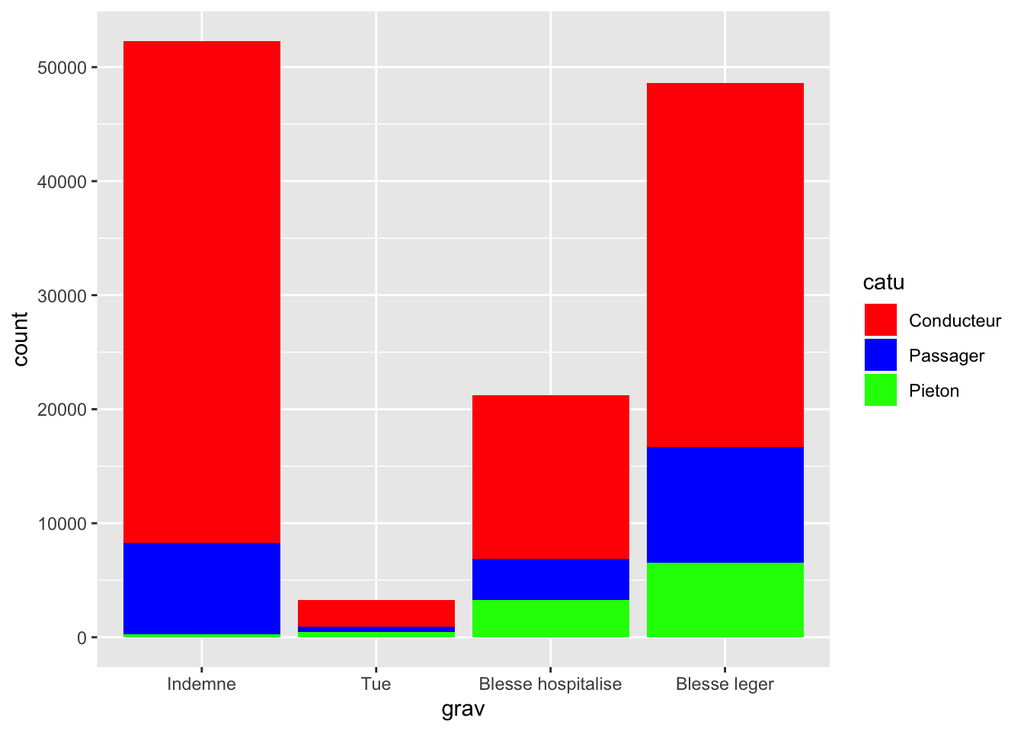

```r
ggplot(data) + aes(x=grav, fill = catu) + geom_bar()+
  scale_fill_manual(values = c('red', 'blue', 'green'),labels=c("Conducteur", "Passager", "Pieton"))
```

17. Créer un nouveau jeu de données ne contenant que les observations des personnes tuées lors d’un accident de la route

```r
data_mort <- subset(data, grav == "Tue")
```

18. Quel département a été le plus meurtrier en 2018 ? Le moins ?

```r
which.max(table(data_mort$dep))
```

```
## 130
##  13
```

```r
which.min(table(data_mort$dep))
```

```
## 480
##  49
```

16. Tracer l’évolution du nombre de morts par jours au cours de l’année 2018

```r
library(dplyr)
```

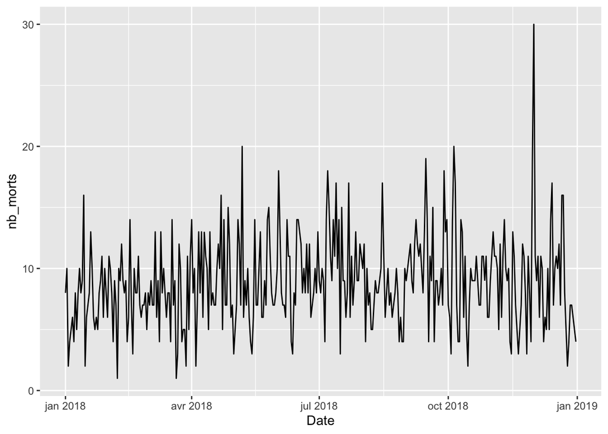

```r
#Methode 1
nb_mort_jour <- data.frame(table(data_mort$date))
colnames(nb_mort_jour) <- c("Date", "nb_morts")
nb_mort_jour$Date <- as.Date(nb_mort_jour$Date)

ggplot(nb_mort_jour) + aes(x=Date, y = nb_morts) + geom_line()
```

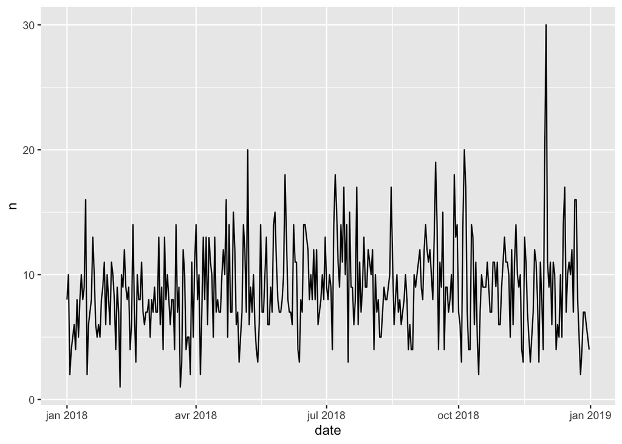

```r
#Methode 2
data_mort %>% group_by(date) %>% count() %>% ggplot() + aes(x=date, y = n) + geom_line()
```

```r
data_mort$age_classe <- cut(data_mort$age, breaks = c(0, 17, 25, 35, 50, 65, 110), include.lowest=T)
```

18. Tracer l’évolution mensuelle nombre d’accidents mortels en 2018 en France pour chacune des différentes classes d’âge crées ci-dessus.

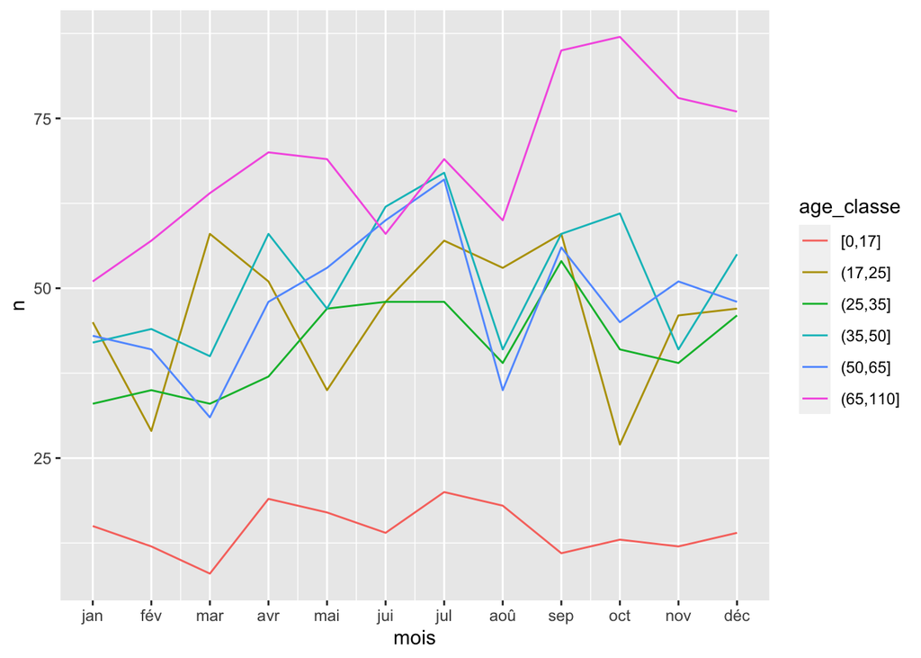

```r
data_mort %>% group_by(age_classe, mois) %>% count() %>%
  ggplot() + aes(x=mois, y=n, colour = age_classe) + geom_line() +
 scale_x_continuous(breaks = unique(data_mort$mois),
                    labels = month(unique(data_mort$mois), label = T))
```